# Creating simple websites with Quarto + GitHub Pages

Introduction to Quarto for building websites

[Kathleen Zeglinski](https://github.com/kzeglinski) & [Danyang Dai](https://github.com/DanyangDai)

## What is Quarto?

Quarto is an open-source scientific and technical publishing system built to help create high-quality reproducible documents, presentations, websites and more.

Does it sound somewhat familiar?

Yes! Quarto is the next generation of R Markdown.

[figure not shown]

## Building website with Quarto

Today, we are going to focus on building website using Quarto. For more detailed information, see https://quarto.org/docs/websites/.

## Why Quarto

Before Quarto time, `blogdown`<sup>1</sup> and `distill` were used for building and publishing website.

[figure not shown]

[^1]: For more information: [Blogdown Website workshop](https://blogdownworkshop.netlify.app/#1)

## Why Quarto

Coding is too hard, I want to use [WordPress](https://wordpress.com)!

While WordPress is open-source and free, you will need to pay for hosting to publish your website.

## Why Quarto

Actually…

Quarto Website is super easy!

[figure not shown]

## More reasons for using Quarto:

### Cool examples for some website made with Quarto

[R-Ladies Melbourne](https://r-ladiesmelbourne.github.io)

[WEHI R Course](https://kzeglinski.github.io/new_wehi_r_course/)

[PhD Diary](https://danyangdai.github.io/PhD_diary/)

## You are just a few click away from having your own website!

To create a Quarto website, follow the instruction below:

[figure not shown]

## Quarto basic for building website

[figure not shown]

## Quarto basic for building website

[figure not shown]

YAML: Controls configuration, navigation, metadata

## Quarto basic for building website

[figure not shown]

This part is the same for any qmd or rmd file. Markdown is used for base syntax for content writing.

## Quarto basic for building website

[figure not shown]

Within this R chunk, everything is the same with writing a R script.

## What do all the different files do?

[figure not shown]

- The `index.qmd` file is essential. When a `qmd` file is named as `index`, it will automatically be used as the home page.
- The `index.qmd` file must be named exactly as it is `index.qmd`.
- The `index.qmd` file must be placed in the root folder next to the `_quarto.yml`.

## What do all the different files do?

[figure not shown]

- The `about.qmd` is the the About page in your website.

## What do all the different files do?

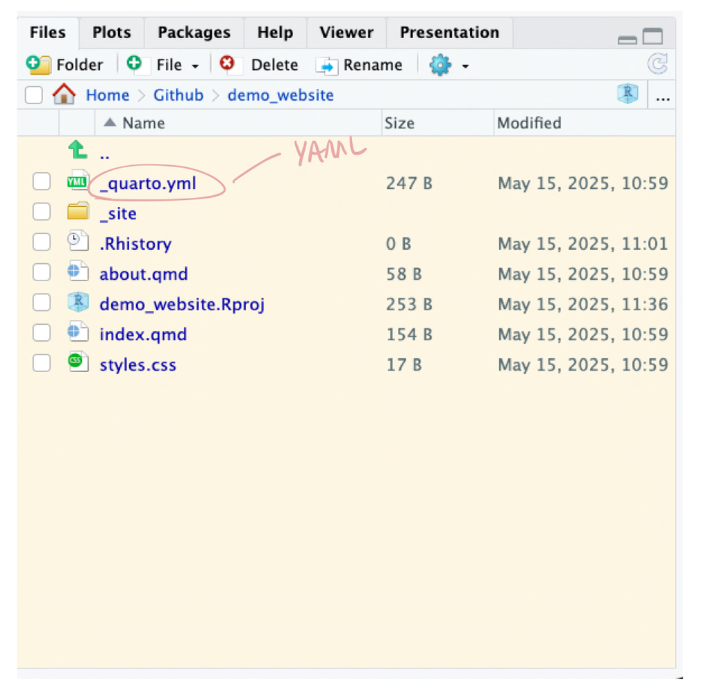

- The `_quarto.yml` is the control center for our Quarto website.
- The `_quarto.yml` uses YAML language and unifies all pages under one layout and configuration.

## What do all the different files do?

[figure not shown]

- The `styles.css` is a custom CSS file to help make your website pretty.
- This is where you can get creative and customised your website.

## What do all the different files do?

[figure not shown]

- This `_site` folder will be automatically generated once you clicked the `Render` function.
- ❌ DO NOT edit anything in the `_site` folder. But you can delete and re-render.

## How do it all come together?

```
my-website/
├── _quarto.yml       ← 🔧 Configuration file
├── styles.css        ← 🎨 Custom styling (optional)
├── index.qmd         ← 🏠 Home page
├── about.qmd         ← 📄 Additional page
└── _site/            ← 🌐 Rendered website output (auto-generated)
```

The goal today is to make sure that everyone will have a working website published on Github Page to take home!

## Some code for your terminal

- To clone the Github Repo:

```
git clone https://github.com/yourusername/my-website.git
```

- Push to Github:

```
git add .
git commit -m "Initial Quarto site"
git push origin main
```

Alternatively, you can use GitHub Desktop for Git management.

- Publish website

```
quarto publish gh-pages
```

## More about Quarto

- To learn more about Quarto see https://quarto.org.
- To learn more about building website with Quarto see https://quarto.org/docs/websites/.

## Acknowledgment

- We would like to thank DiUS for hosting us.
- We would like to thank the Qurto developing team for making it possible!
- [Daidai: danyang.dai@uq.edu.au](https://github.com/DanyangDai)
- [Kathleen: zeglinski.k@wehi.edu.au](https://github.com/kzeglinski)

## Let’s Get to Work!

[figure not shown]